# R code Faraz

Faraz Younus

2023-05-28

## R Markdown

```r
attach(df)
summary(df)
```

```
##      cancer          gender         N/a_col           st1
##  Min.   :1.000   Min.   :1.000   Min.   :38.00   Min.   :  20.0
##  1st Qu.:2.000   1st Qu.:1.000   1st Qu.:56.50   1st Qu.: 119.5
##  Median :3.000   Median :1.000   Median :66.00   Median : 245.0
##  Mean   :2.968   Mean   :1.381   Mean   :64.08   Mean   : 475.6
##  3rd Qu.:4.000   3rd Qu.:2.000   3rd Qu.:72.50   3rd Qu.: 452.5
##  Max.   :6.000   Max.   :2.000   Max.   :93.00   Max.   :4288.0
##       st2              st3              st4
##  Min.   :  18.0   Min.   :   8.0   Min.   :10.00
##  1st Qu.: 109.5   1st Qu.:  50.0   1st Qu.:18.50
##  Median : 199.0   Median : 124.0   Median :30.00
##  Mean   : 270.1   Mean   : 200.4   Mean   :33.97
##  3rd Qu.: 392.0   3rd Qu.: 260.0   3rd Qu.:41.00
##  Max.   :1056.0   Max.   :1267.0   Max.   :91.00
```

MANOVA in R can be used to determine whether there are significant differences between multiple groups on multiple dependent variables. However, it does not tell you which groups differ from the rest. This can be determined using a post-hoc test, such as Linear Discriminant Analysis (LDA).

MANOVA has several assumptions, including:

Multivariate normality: Each combination of independent and dependent variables should have a multivariate normal distribution. This can be verified using Shapiro-Wilk’s test. Linearity: Dependent variables should have a linear relationship with each group (factor) of the independent variable. No multicollinearity: Dependent variables should not have very high correlations. No outliers: There should not be any outliers in the dependent variables.

This isn’t important in our case.

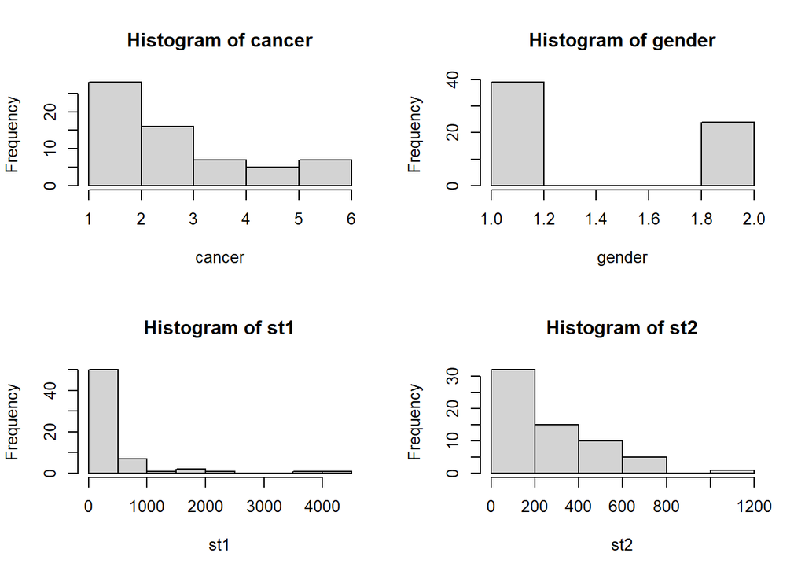

```r
par(mfrow = c(2, 2))
# This code allows use to get histograms of the distributions of different variables
hist(cancer)
hist(gender)
hist(st1)
hist(st2)
```

```r
library(car)
# Create a factor variable for the independent variable

group <- factor(cancer)

#group<- levels(factor)

# Perform the MANOVA
result<-manova(cbind(st1, st2, st3, st4) ~ group, data = df)

# Print the MANOVA results
summary(result)
```

```
##           Df  Pillai approx F num Df den Df    Pr(>F)
## group      5 0.85343    3.092     20    228 2.189e-05 ***
## Residuals 57
## ---
## Signif. codes:  0 '***' 0.001 '**' 0.01 '*' 0.05 '.' 0.1 ' ' 1
```

Pillai: The Pillai’s trace statistic is a multivariate test statistic used in MANOVA. It measures the overall effect of the grouping variable on the dependent variables. The reported Pillai’s trace value is 0.85343.

Pr(>F): This column displays the p-value associated with the approximate F-test. It indicates the probability of observing the obtained F-statistic (or a more extreme value) under the null hypothesis of no group effect. In this case, the p-value is 2.189e-05, which is very small, suggesting strong evidence against the null hypothesis.

Overall, the MANOVA results suggest that there is a significant multivariate effect of the grouping variable on the dependent variables (st1, st2, st3, st4).

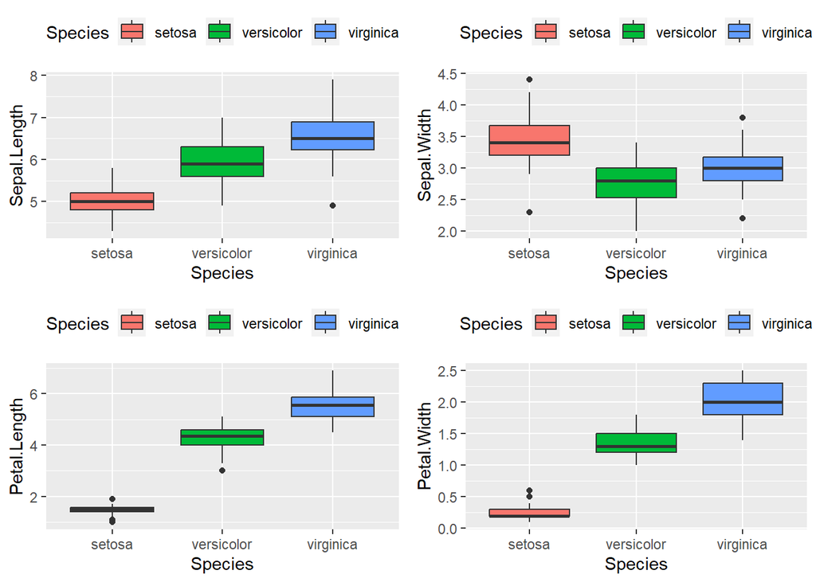

```r
# Perform MANOVA
library(ggplot2)
library(gridExtra)

box_sl <- ggplot(iris, aes(x = Species, y = Sepal.Length, fill = Species)) +
  geom_boxplot() +
  theme(legend.position = "top")
box_sw <- ggplot(iris, aes(x = Species, y = Sepal.Width, fill = Species)) +
  geom_boxplot() +
  theme(legend.position = "top")
box_pl <- ggplot(iris, aes(x = Species, y = Petal.Length, fill = Species)) +
  geom_boxplot() +
  theme(legend.position = "top")
box_pw <- ggplot(iris, aes(x = Species, y = Petal.Width, fill = Species)) +
  geom_boxplot() +
  theme(legend.position = "top")

grid.arrange(box_sl, box_sw, box_pl, box_pw, ncol = 2, nrow = 2)
```

```r
dependent_vars <- cbind(iris$Sepal.Length, iris$Sepal.Width, iris$Petal.Length, iris$Petal.Width)
independent_var <- iris$Species

manova_model <- manova(dependent_vars ~ independent_var, data = iris)
summary(manova_model)
```

```
##                  Df Pillai approx F num Df den Df    Pr(>F)
## independent_var   2 1.1919   53.466      8    290 < 2.2e-16 ***
## Residuals       147
## ---
## Signif. codes:  0 '***' 0.001 '**' 0.01 '*' 0.05 '.' 0.1 ' ' 1
```

```r
library(effectsize)

eta_squared(manova_model)
```

```
## # Effect Size for ANOVA (Type I)
##
## Parameter       | Eta2 (partial) |       95% CI
## -----------------------------------------------
## independent_var |           0.60 | [0.54, 1.00]
##
## - One-sided CIs: upper bound fixed at [1.00].
```

```r
library(MASS)

iris_lda <- lda(independent_var ~ dependent_vars, CV = F)
iris_lda
```

```
## Call:
## lda(independent_var ~ dependent_vars, CV = F)
##
## Prior probabilities of groups:
##     setosa versicolor  virginica
##  0.3333333  0.3333333  0.3333333
##
## Group means:
##            dependent_vars1 dependent_vars2 dependent_vars3 dependent_vars4
## setosa               5.006           3.428           1.462           0.246
## versicolor           5.936           2.770           4.260           1.326
## virginica            6.588           2.974           5.552           2.026
##
## Coefficients of linear discriminants:
##                        LD1         LD2
## dependent_vars1  0.8293776  0.02410215
## dependent_vars2  1.5344731  2.16452123
## dependent_vars3 -2.2012117 -0.93192121
## dependent_vars4 -2.8104603  2.83918785
##
## Proportion of trace:
##    LD1    LD2
## 0.9912 0.0088
```

```r
LDA_Dataframe <- data.frame(
  species = iris[, "Species"],
  lda = predict(iris_lda)$x
)
head(LDA_Dataframe)
```

```
##   species  lda.LD1    lda.LD2
## 1  setosa 8.061800  0.3004206
## 2  setosa 7.128688 -0.7866604
## 3  setosa 7.489828 -0.2653845
## 4  setosa 6.813201 -0.6706311
## 5  setosa 8.132309  0.5144625
## 6  setosa 7.701947  1.4617210
```

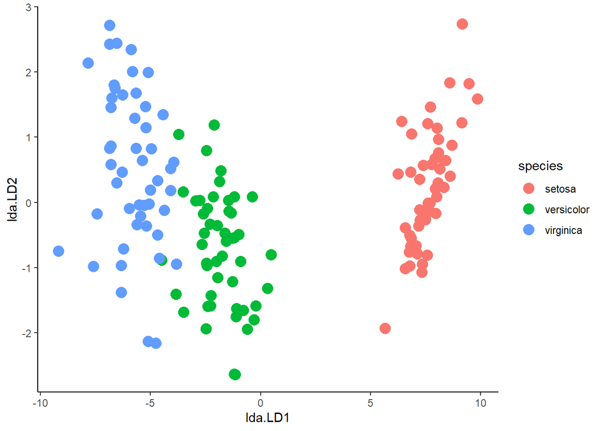

```r
ggplot(LDA_Dataframe) +
  geom_point(aes(x = lda.LD1, y = lda.LD2, color = species), size = 4) +
  theme_classic()
```